# Ford GoBike Trip Duration per Datetime and User Type

## Abdulwasiu Tiamiyu

## Investigation Overview

In this investigation, I wanted to take a look at how the duration of trips changes with respect to DateTime and customer type. The main focus was on hours of the day, days of the week and customer type.

## Dataset Overview

The data consists of information regarding approximately 183,000 rides made in a bike-sharing system covering the greater San Francisco Bay area. The data features include duration (secs) and others such as DateTime, customer type, and gender, as well as additional variables such as member's year of birth, start and end station name, start and end station longitude and latitude, start and end station unique id among others. About 8000 data points were removed from the analysis due to inconsistencies or missing information.

## Distribution of Rides by Days

Most rides were taken on Thursdays and Tuesdays. Weekends have the lowest trip records.

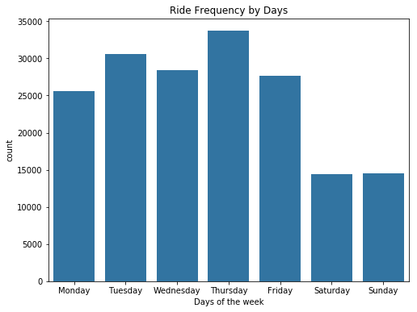

## Distribution of Rides by Hours

The higher ride frequencies for morning (8th and 9th hours) and evening (17th and 18th hours) can be linked to rush hours where people leave for work and come back later in the evening.

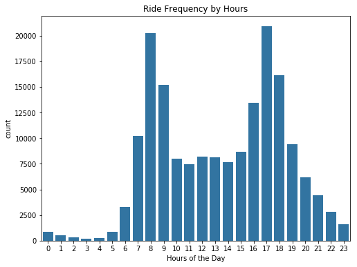

## Distribution of Rides by User Type

Subscribers account for over 90% of the total rides

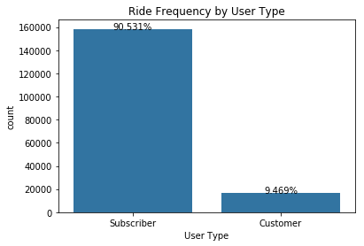

## Trip Duration across Days

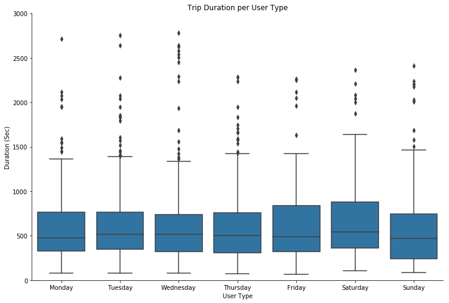

## Trip Duration across Customer Types

Customer user type trips take a longer duration than subscriber user type

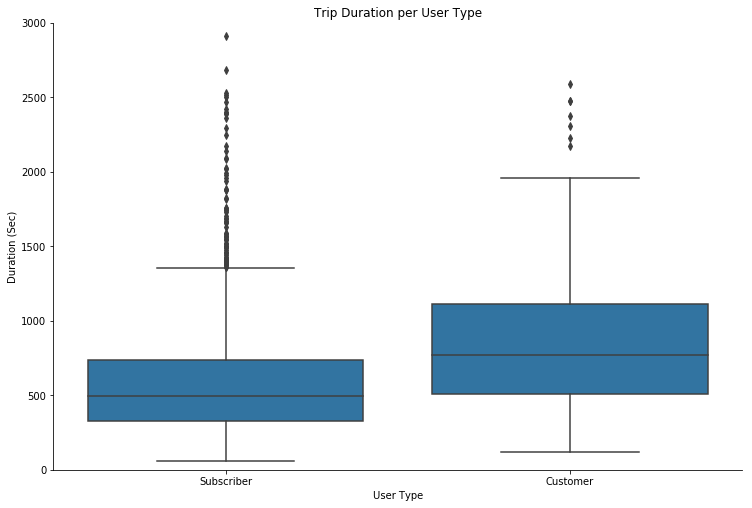